# STAT 650 - Midterm Project Guidelines

## Data Selction and Data Description:

## Dataset Selection

The dataset which I chose for this project is the Netflix Movies and TV Shows dataset, which is needed to create the movie and TV show recommendation system, this dataset contains information about the content which is available on netflix.

The dataset is publicly available and has been downloaded from Kaggle, which is a famous platform for machine learning and data science projects. It was created to list out all the shows and movies that are available on netflix

## Dataset Description

The dataset contains information on over 8,800 unique titles, which includes both TV shows and movies available on netflix, with so many entries we can gain rich foundation for our analysis and system development

## Variables

The dataset which I chose has a diverse range of variables some of the key variables are:

● Title: Describes the name of the movie or the TV show

● Director: Describes the information about the director of the movie and TV show

● Cast: contains the list of all the actors who acted in the movie or the TV show

● Rating: Describes the information of the age certification of the movie (e.g , PG-13, TV-MA)

● Listed_in: Describes the information on the genre of the movie

## Quantitative Variables:

● Release_Year: Describes the information on when the movie or the show was released

● Duration: Tells us about how long the movie or the show is.

The rich dataset provides us with good opportunity to conduct in-depth analysis and development of a good movie recommendation system, the combination of both quantitative and categorical variables will allow for diverse analytical approaches which includes content based filtering and collaborative filtering.

## Step - 1 Importing the Data

```python
import pandas as pd
import numpy as np

# Load the dataset
netflix_df = pd.read_csv('netflix_titles.csv')
```

## Step - 1.1 Understanding the Data

```python
# Display the first few rows and basic information
print(netflix_df.head())
```

```
  show_id     type                  title         director  \
0      s1    Movie   Dick Johnson Is Dead  Kirsten Johnson
1      s2  TV Show          Blood & Water              NaN
2      s3  TV Show              Ganglands  Julien Leclercq
3      s4  TV Show  Jailbirds New Orleans              NaN
4      s5  TV Show           Kota Factory              NaN

                                                cast        country  \
0                                                NaN  United States
1  Ama Qamata, Khosi Ngema, Gail Mabalane, Thaban...   South Africa
2  Sami Bouajila, Tracy Gotoas, Samuel Jouy, Nabi...            NaN
3                                                NaN            NaN
4  Mayur More, Jitendra Kumar, Ranjan Raj, Alam K...          India

           date_added  release_year rating   duration  \
```

[output cut: 19 more lines]

```python
print(netflix_df.columns)
```

```
Index(['show_id', 'type', 'title', 'director', 'cast', 'country', 'date_added',
       'release_year', 'rating', 'duration', 'listed_in', 'description'],
      dtype='object')
```

```python
print(netflix_df.isnull().sum())
```

```
show_id            0
type               0
title              0
director        2634
cast             825
country          831
date_added        10
release_year       0
rating             4
duration           3
listed_in          0
description        0
dtype: int64
```

## Step - 2 Data Pre-Processing

## Step - 2.1 Handling Missing Values

```python
import pandas as pd
import numpy as np

# Handle missing values in categorical columns
categorical_cols = ['type', 'title', 'director', 'cast', 'country', 'rating', 'listed_in', 'description']
for col in categorical_cols:
    netflix_df[col] = netflix_df[col].fillna('Unknown')

# Handle missing values in date_added column
netflix_df['date_added'] = pd.to_datetime(netflix_df['date_added'], errors='coerce')
netflix_df = netflix_df.dropna(subset=['date_added'])

# Handle missing values in release_year (numeric column)
netflix_df['release_year'] = netflix_df['release_year'].fillna(netflix_df['release_year'].median())

# Handle duration column (mixed numeric and categorical)
netflix_df[['duration_value', 'duration_unit']] = netflix_df['duration'].str.split(' ', n=1, expand=True)
netflix_df['duration_value'] = pd.to_numeric(netflix_df['duration_value'], errors='coerce')
netflix_df['duration_value'] = netflix_df['duration_value'].fillna(netflix_df['duration_value'].median())
netflix_df['duration_unit'] = netflix_df['duration_unit'].fillna(netflix_df['duration_unit'].mode()[0])

# Reconstruct the duration column
netflix_df['duration'] = netflix_df['duration_value'].astype(str) + ' ' + netflix_df['duration_unit']

# Drop temporary columns
netflix_df = netflix_df.drop(columns=['duration_value', 'duration_unit'])

# Verify the changes
print(netflix_df.isnull().sum())
```

```
show_id         0
type            0
title           0
director        0
cast            0
country         0
date_added      0
release_year    0
rating          0
duration        0
listed_in       0
description     0
dtype: int64
```

## Step - 2.2: Removing Duplicates

```python
# Check for duplicates
print(netflix_df.duplicated().sum())

# Remove duplicates if any
netflix_df = netflix_df.drop_duplicates()
```

```
0
```

## Step - 2.3: Correiting the inconsistencies and erros in data

```python
# Convert text to lowercase
text_columns = ['title', 'director', 'cast', 'country', 'listed_in', 'description']
for col in text_columns:
    netflix_df[col] = netflix_df[col].str.lower()

# Trim whitespace
netflix_df = netflix_df.apply(lambda x: x.str.strip() if x.dtype == "object" else x)
```

```python
# Convert 'release_year' to integer
netflix_df['release_year'] = pd.to_numeric(netflix_df['release_year'], errors='coerce').astype('Int64')

# Convert 'date_added' to datetime
netflix_df['date_added'] = pd.to_datetime(netflix_df['date_added'], errors='coerce')
```

```python
# Split duration into value and unit
netflix_df[['duration_value', 'duration_unit']] = netflix_df['duration'].str.split(' ', expand=True)
netflix_df['duration_value'] = pd.to_numeric(netflix_df['duration_value'], errors='coerce')

# Convert movie durations to minutes if in hours
mask = netflix_df['duration_unit'] == 'h'
netflix_df.loc[mask, 'duration_value'] *= 60
netflix_df.loc[mask, 'duration_unit'] = 'min'
```

```python
# Split 'listed_in' into separate genres
netflix_df['genres'] = netflix_df['listed_in'].str.split(',')

# If you want to clean up the genre names (remove leading/trailing whitespace)
netflix_df['genres'] = netflix_df['genres'].apply(lambda x: [genre.strip() for genre in x] if isinstance(x, list) else x)

# Print the first few rows to verify the changes
print(netflix_df[['title', 'listed_in', 'genres']].head())
```

```
                   title                                          listed_in  \
0   dick johnson is dead                                      documentaries
1          blood & water    international tv shows, tv dramas, tv mysteries
2              ganglands  crime tv shows, international tv shows, tv act...
3  jailbirds new orleans                             docuseries, reality tv
4           kota factory  international tv shows, romantic tv shows, tv ...

                                              genres
0                                    [documentaries]
1  [international tv shows, tv dramas, tv mysteries]
2  [crime tv shows, international tv shows, tv ac...
3                           [docuseries, reality tv]
4  [international tv shows, romantic tv shows, tv...
```

```python
print(netflix_df.dtypes)
```

```
show_id                   object
type                      object
title                     object
director                  object
cast                      object
country                   object
date_added        datetime64[ns]
release_year               Int64
rating                    object
duration                  object
listed_in                 object
description               object
duration_value           float64
duration_unit             object
genres                    object
dtype: object
```

```python
import pandas as pd
import numpy as np
import matplotlib.pyplot as plt
import seaborn as sns

# Load the dataset
netflix_df = pd.read_csv('netflix_titles.csv')

# 1. Standardize text data
text_columns = ['title', 'director', 'cast', 'country', 'listed_in', 'description']
for col in text_columns:
    netflix_df[col] = netflix_df[col].astype(str).str.strip().str.lower()

# 2. Handle the 'type' column
netflix_df['type'] = netflix_df['type'].str.lower()
valid_types = ['movie', 'tv show']
netflix_df.loc[~netflix_df['type'].isin(valid_types), 'type'] = 'unknown'

# 3. Clean up the 'rating' column
netflix_df['rating'] = netflix_df['rating'].str.upper()

# 4. Handle the 'duration' column
netflix_df['duration'] = netflix_df['duration'].astype(str).str.lower()
netflix_df[['duration_value', 'duration_unit']] = netflix_df['duration'].str.extract(r'(\d+)\s*(\w+)')
netflix_df['duration_value'] = pd.to_numeric(netflix_df['duration_value'], errors='coerce')

# Standardize duration units
netflix_df.loc[netflix_df['duration_unit'].str.contains('season', na=False), 'duration_unit'] = 'seasons'
netflix_df.loc[netflix_df['duration_unit'].str.contains('min', na=False), 'duration_unit'] = 'min'

# 5. Clean up 'release_year'
netflix_df['release_year'] = pd.to_numeric(netflix_df['release_year'], errors='coerce')
current_year = pd.Timestamp.now().year
netflix_df.loc[netflix_df['release_year'] > current_year, 'release_year'] = np.nan

# 6. Handle 'date_added'
netflix_df['date_added'] = pd.to_datetime(netflix_df['date_added'], errors='coerce')

# 7. Clean up 'listed_in' (genres)
netflix_df['listed_in'] = netflix_df['listed_in'].str.split(',')
netflix_df['listed_in'] = netflix_df['listed_in'].apply(lambda x: tuple(sorted(genre.strip() for genre in x)) if isinstance(x, list) else x)

# 8. Remove any completely duplicate rows
netflix_df = netflix_df.drop_duplicates()

# 9. Check for and handle any remaining missing values
for column in netflix_df.columns:
    if netflix_df[column].dtype == 'object':
        netflix_df[column] = netflix_df[column].fillna('Unknown')
    elif netflix_df[column].dtype in ['int64', 'float64']:
        netflix_df[column] = netflix_df[column].fillna(netflix_df[column].median())

# Print summary of the cleaned dataset
print(netflix_df.info())
print("\nSample of cleaned data:")
print(netflix_df.head())

# Check for any remaining issues
print("\nUnique values in 'type' column:", netflix_df['type'].unique())
print("\nUnique values in 'rating' column:", netflix_df['rating'].unique())
print("\nRange of 'release_year':", netflix_df['release_year'].min(), "to", netflix_df['release_year'].max())
```

```
<class 'pandas.core.frame.DataFrame'>
RangeIndex: 8807 entries, 0 to 8806
Data columns (total 14 columns):
 #   Column          Non-Null Count  Dtype
---  ------          --------------  -----
 0   show_id         8807 non-null   object
 1   type            8807 non-null   object
 2   title           8807 non-null   object
 3   director        8807 non-null   object
 4   cast            8807 non-null   object
 5   country         8807 non-null   object
 6   date_added      8709 non-null   datetime64[ns]
 7   release_year    8807 non-null   float64
 8   rating          8807 non-null   object
 9   duration        8807 non-null   object
 10  listed_in       8807 non-null   object
 11  description     8807 non-null   object
 12  duration_value  8807 non-null   float64
 13  duration_unit   8807 non-null   object
dtypes: datetime64[ns](1), float64(2), object(11)
memory usage: 963.4+ KB
None

Sample of cleaned data:
  show_id     type                  title         director  \
0      s1    movie   dick johnson is dead  kirsten johnson
1      s2  tv show          blood & water              nan
2      s3  tv show              ganglands  julien leclercq
3      s4  tv show  jailbirds new orleans              nan
4      s5  tv show           kota factory              nan

                                                cast        country  \
0                                                nan  united states
1  ama qamata, khosi ngema, gail mabalane, thaban...   south africa
2  sami bouajila, tracy gotoas, samuel jouy, nabi...            nan
3                                                nan            nan
4  mayur more, jitendra kumar, ranjan raj, alam k...          india

  date_added  release_year rating   duration  \
0 2021-09-25        2020.0  PG-13     90 min
```

[output cut: 17 more lines]

```
4  in a city of coaching centers known to train i...             2.0

  duration_unit
0           min
1       seasons
2       seasons
3       seasons
4       seasons

Unique values in 'type' column: ['movie' 'tv show']

Unique values in 'rating' column: ['PG-13' 'TV-MA' 'PG' 'TV-14' 'TV-PG' 'TV-Y' 'TV-Y7' 'R' 'TV-G' 'G'
 'NC-17' '74 MIN' '84 MIN' '66 MIN' 'NR' 'Unknown' 'TV-Y7-FV' 'UR']

Range of 'release_year': 1925.0 to 2021.0
```

## Step - 3: Exploratory Data Analysis (EDA)

## Step - 3.1: Univariate Analysis

```python
import pandas as pd
import numpy as np
import matplotlib.pyplot as plt
import seaborn as sns

# Set the style for our plots
plt.style.use('seaborn-v0_8')
```

```python
numeric_columns = ['release_year', 'duration_value']

#here we can print the basic statsics of the netflix data

for col in numeric_columns:
    print(f"\nSummary Statistics for {col}:")
    print(f"Mean: {netflix_df[col].mean():.2f}")
    print(f"Median: {netflix_df[col].median():.2f}")
    print(f"Mode: {netflix_df[col].mode()[0]:.2f}")
    print(f"Standard Deviation: {netflix_df[col].std():.2f}")
    print(f"Minimum: {netflix_df[col].min():.2f}")
    print(f"Maximum: {netflix_df[col].max():.2f}")
    print(f"25th Percentile: {netflix_df[col].quantile(0.25):.2f}")
    print(f"75th Percentile: {netflix_df[col].quantile(0.75):.2f}")
    print(f"Skewness: {netflix_df[col].skew():.2f}")
    print(f"Kurtosis: {netflix_df[col].kurtosis():.2f}")

categorical_columns = ['type', 'rating', 'country']

for col in categorical_columns:
    print(f"\nTop 5 categories in {col}:")
    print(netflix_df[col].value_counts().nlargest(5))
```

```
Summary Statistics for release_year:
Mean: 2014.18
Median: 2017.00
Mode: 2018.00
Standard Deviation: 8.82
Minimum: 1925.00
Maximum: 2021.00
25th Percentile: 2013.00
75th Percentile: 2019.00
Skewness: -3.45
Kurtosis: 16.23

Summary Statistics for duration_value:
Mean: 69.85
Median: 88.00
Mode: 1.00
Standard Deviation: 50.81
Minimum: 1.00
Maximum: 312.00
25th Percentile: 2.00
75th Percentile: 106.00
Skewness: -0.19
Kurtosis: -1.08

Top 5 categories in type:
type
movie      6131
tv show    2676
Name: count, dtype: int64

Top 5 categories in rating:
rating
TV-MA    3207
TV-14    2160
TV-PG     863
R         799
PG-13     490
Name: count, dtype: int64

Top 5 categories in country:
country
united states     2818
india              972
nan                831
united kingdom     419
japan              245
Name: count, dtype: int64
```

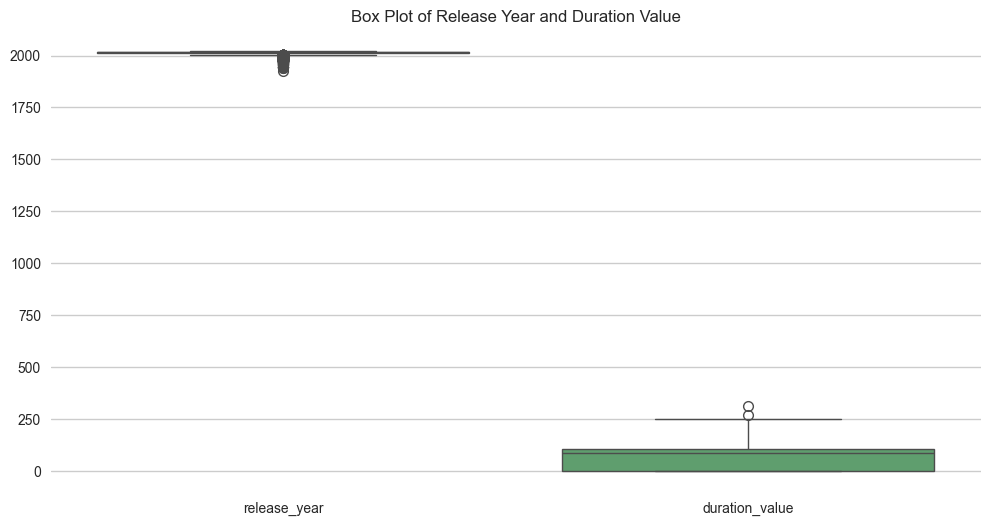

```python
import matplotlib.pyplot as plt
import seaborn as sns

# Set the style for better-looking plots
sns.set_style("whitegrid")

# Function to create and display plots
def create_plot(plot_func, title):
    plt.figure(figsize=(12, 6))
    plot_func()
    plt.title(title)
    plt.tight_layout()
    plt.show()

# 1. Combined Box Plot for Release Year and Duration Value
plt.figure(figsize=(12, 6))
sns.boxplot(data=netflix_df[['release_year', 'duration_value']])
plt.title('Box Plot of Release Year and Duration Value')
plt.show()
```

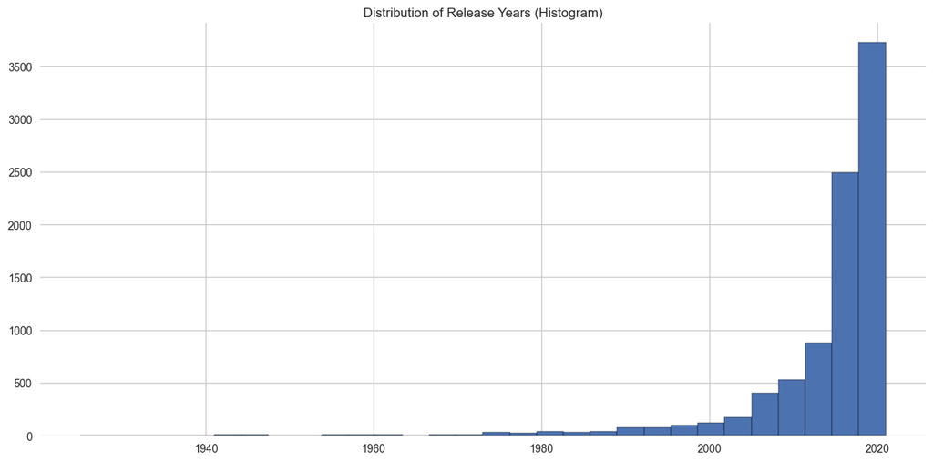

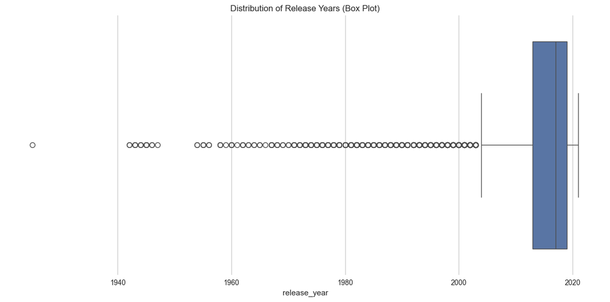

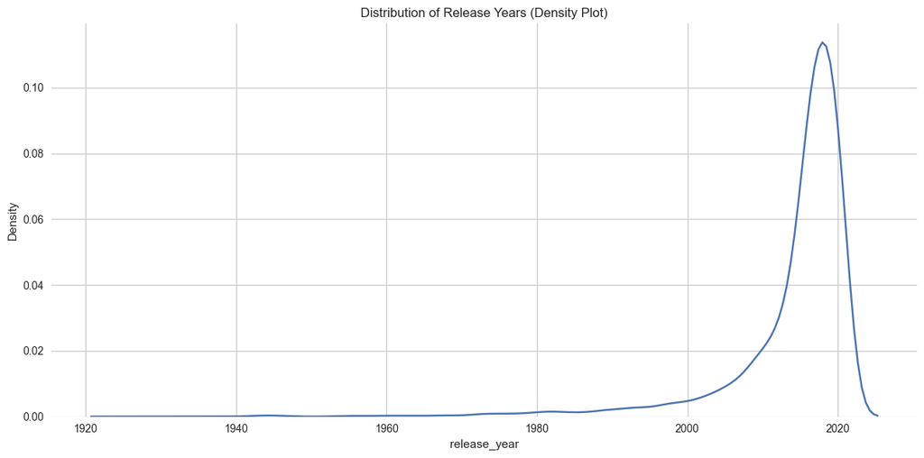

```python
# 2. Distribution of Release Year Visualizations

# Histogram
create_plot(
    lambda: plt.hist(netflix_df['release_year'], bins=30, edgecolor='black'),
    'Distribution of Release Years (Histogram)'
)

# Box Plot
create_plot(
    lambda: sns.boxplot(x=netflix_df['release_year']),
    'Distribution of Release Years (Box Plot)'
)

# Density Plot
create_plot(
    lambda: sns.kdeplot(netflix_df['release_year']),
    'Distribution of Release Years (Density Plot)'
)
```

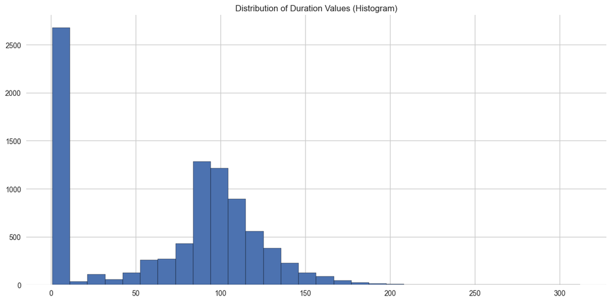

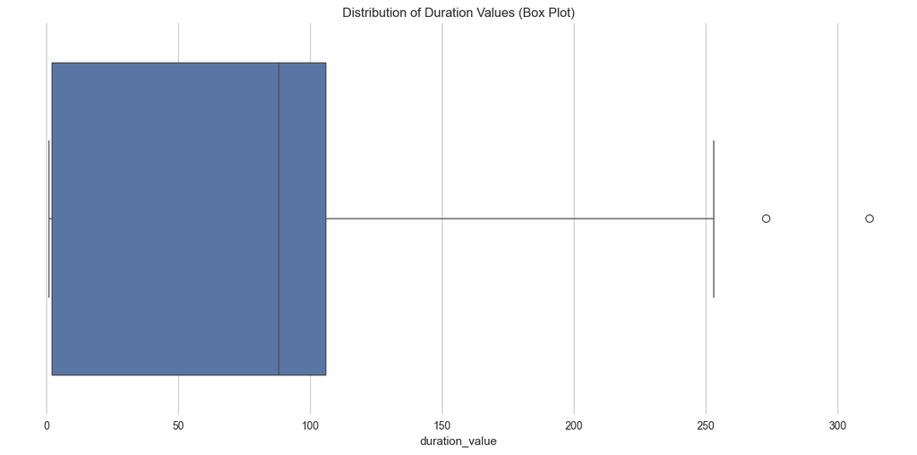

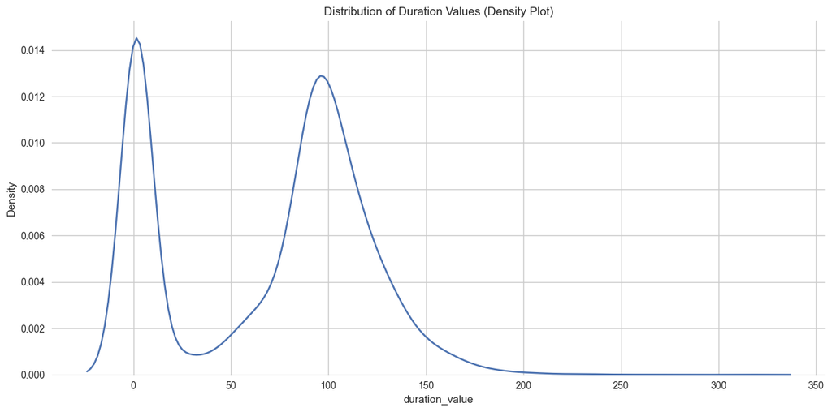

```python
# 3. Distribution of Duration Value Visualizations

# Histogram
create_plot(
    lambda: plt.hist(netflix_df['duration_value'], bins=30, edgecolor='black'),
    'Distribution of Duration Values (Histogram)'
)

# Box Plot
create_plot(
    lambda: sns.boxplot(x=netflix_df['duration_value']),
    'Distribution of Duration Values (Box Plot)'
)

# Density Plot
create_plot(
    lambda: sns.kdeplot(netflix_df['duration_value']),
    'Distribution of Duration Values (Density Plot)'
)
```

## Univariate Analysis - Conclusion

From the above experiment we found out the summary statistics of all the columns present in the data set, which included Count of non-null values, Unique Values, Frequency of top values, mean, minimum, maximum and standard deviation of the numeric columns and most frequent values,

Key insights from summary:

● The dataset has a total of 8,807 entries

● Release year ranges from 1925 to 2021, with a mean of 2014 and a median of 2017.

● The duration value ranges from 1 to 312, with a mean of 69.85 and a median of 88.

The statistics revealed that:

The distribution of release year is negatively skewed (-3.45) with a high kurtosis (16.23), which indicates a concentration of more new releases.

The duration value distribution is slightly negatively skewed (-0.19) with low kurtosis (-1.08), suggesting flat distribution

Categorical Variable Summaries:

The analysis we did told us about top 5 categories for each categorical value:

● Tv shows are less common compared to movies

● ‘TV-MA’ is the most common rating

● The two content-producing countries are “United States” and “India”

The univariate analysis steps showcase a comprehensive overview of each dataset and give us insights on distribution of content types, durations, ratings, release years and countries. The combination of visualisation and summary statistics allows us to gain through understanding of the individual variables, by setting a base for further analysis and development of movie recommendation systems.

## Step - 3.2: Bivariate Analysis

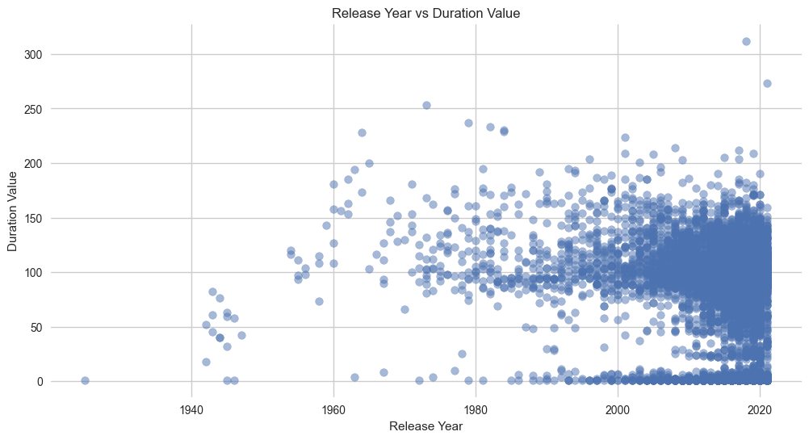

```python
# 1. Scatter plot: Release Year vs Duration Value
plt.figure(figsize=(12, 6))
plt.scatter(netflix_df['release_year'], netflix_df['duration_value'], alpha=0.5)
plt.title('Release Year vs Duration Value')
plt.xlabel('Release Year')
plt.ylabel('Duration Value')
plt.show()
```

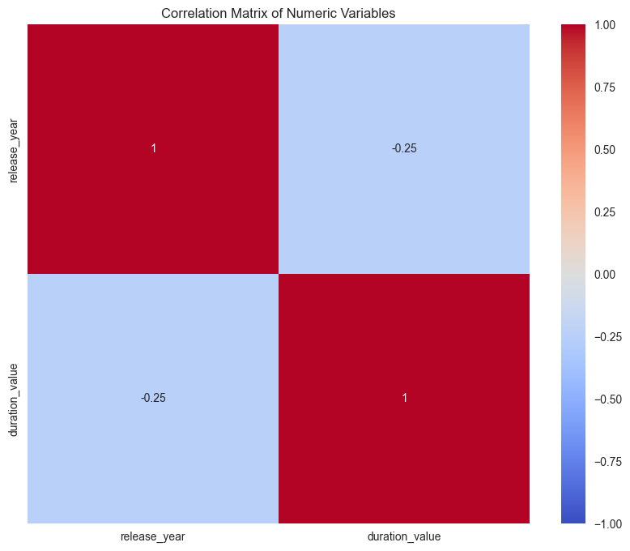

```python
# 2. Correlation matrix for numeric variables
numeric_cols = ['release_year', 'duration_value']
corr_matrix = netflix_df[numeric_cols].corr()

plt.figure(figsize=(10, 8))
sns.heatmap(corr_matrix, annot=True, cmap='coolwarm', vmin=-1, vmax=1, center=0)
plt.title('Correlation Matrix of Numeric Variables')
plt.show()
```

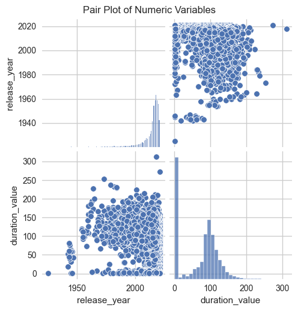

```python
# 3. Pair plot for numeric variables
sns.pairplot(netflix_df[numeric_cols])
plt.suptitle('Pair Plot of Numeric Variables', y=1.02)
plt.show()
```

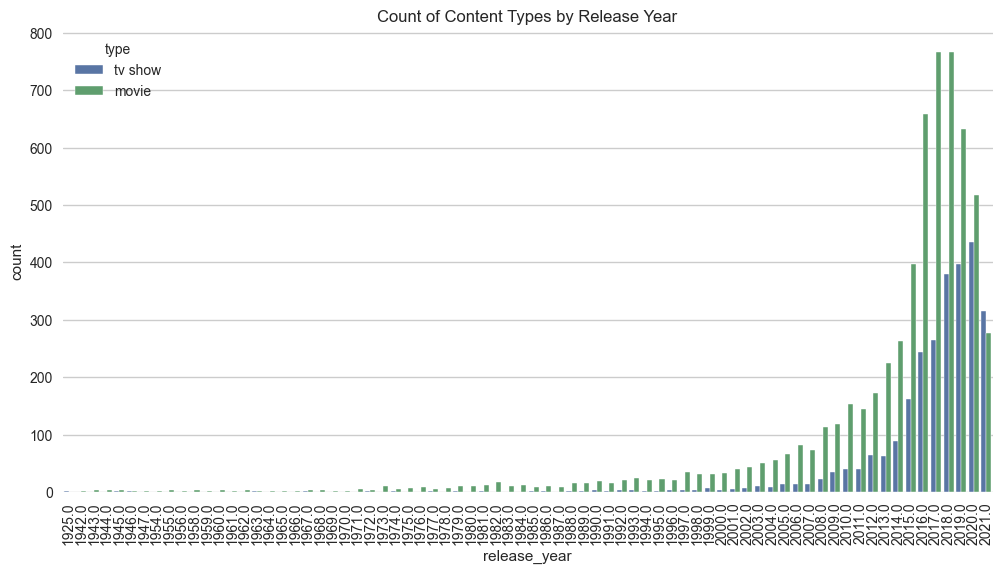

```
Bivariate analysis plots have been displayed.
```

```python
# 7. Count plot: Release Year vs Type
plt.figure(figsize=(12, 6))
sns.countplot(x='release_year', hue='type', data=netflix_df)
plt.title('Count of Content Types by Release Year')
plt.xticks(rotation=90)
plt.show()

print("Bivariate analysis plots have been displayed.")
```

## Bivariate Analysis - Conclusion:

To showcase the Bivariate analysis by focusing on analysing relationships between two variables using various diagrams, In my dataset I chose the two variables to be “Release year” and “Duration”, I chose this because it will help me get an understanding of how the duration of movies and TV shows has been changing over the past few years, one more category which is chose is “Release Year” vs “Type”, to understand the trend of how the shows and movies have been performing across all years

To showcase this trend I implemented many figures to properly understand the data and do the further analysis to create a good movie recommendation system

## Step - 3.3: Multivariate Analysis

```python
import pandas as pd
import numpy as np
import matplotlib.pyplot as plt
import seaborn as sns
from sklearn.preprocessing import StandardScaler
from sklearn.decomposition import PCA

# 1. Prepare the data
# Select numeric columns and encode some categorical columns
numeric_cols = ['release_year', 'duration_value']
netflix_numeric = netflix_df[numeric_cols].copy()

# Encode 'type' as binary (0 for TV Show, 1 for Movie)
netflix_numeric['type_encoded'] = (netflix_df['type'] == 'movie').astype(int)
```

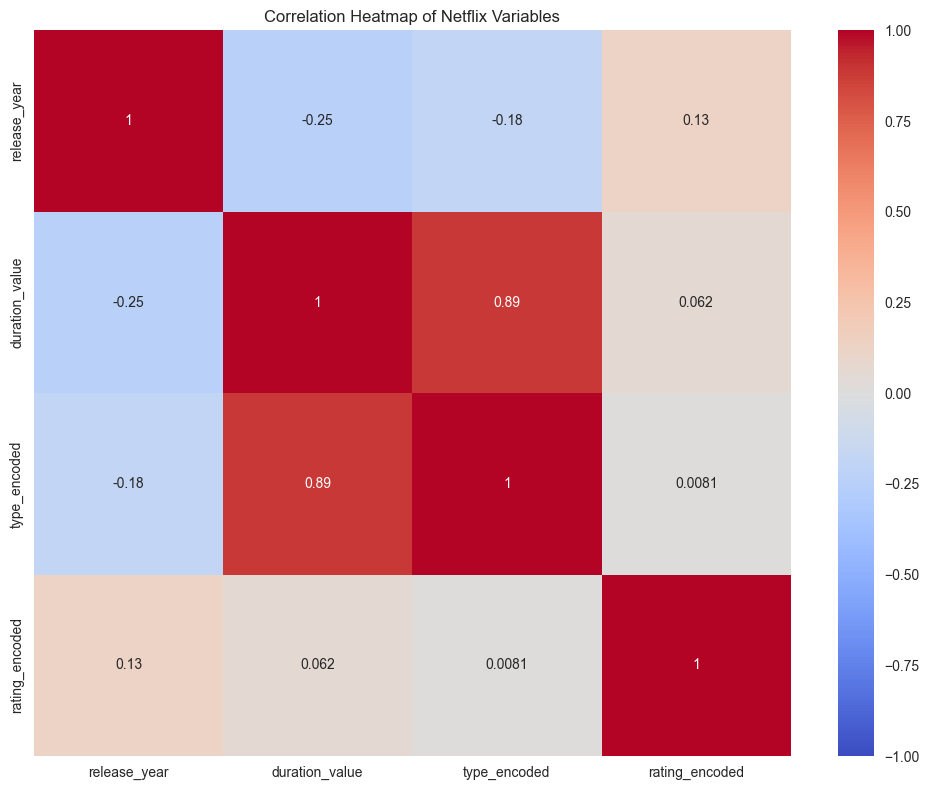

```python
# Encode 'rating' as ordinal
rating_order = ['G', 'TV-Y', 'TV-G', 'PG', 'TV-Y7', 'TV-Y7-FV', 'TV-PG', 'PG-13', 'TV-14', 'R', 'NC-17', 'TV-MA']
netflix_numeric['rating_encoded'] = pd.Categorical(netflix_df['rating'], categories=rating_order, ordered=True).codes

# 2. Create a correlation heatmap
plt.figure(figsize=(10, 8))
sns.heatmap(netflix_numeric.corr(), annot=True, cmap='coolwarm', vmin=-1, vmax=1, center=0)
plt.title('Correlation Heatmap of Netflix Variables')
plt.tight_layout()
plt.show()
```

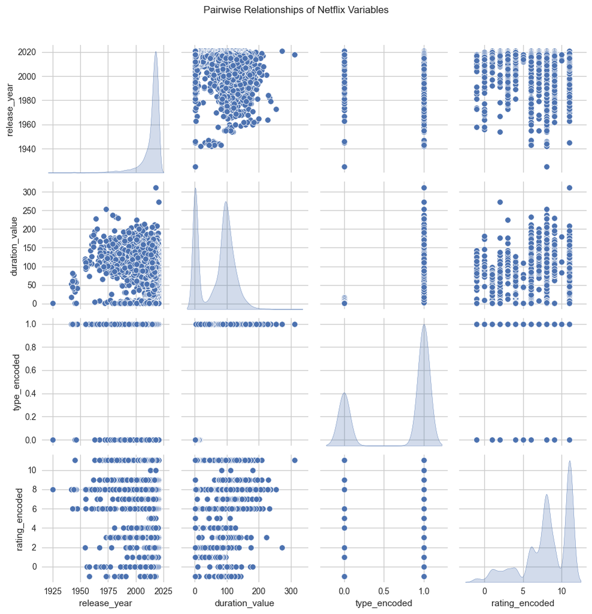

```python
# 3. Visualize pairwise relationships
sns.pairplot(netflix_numeric, diag_kind='kde')
plt.suptitle('Pairwise Relationships of Netflix Variables', y=1.02)
plt.tight_layout()
plt.show()
```

```python
# 4. Perform Principal Component Analysis (PCA)
# Standardize the features
scaler = StandardScaler()
netflix_scaled = scaler.fit_transform(netflix_numeric)

# Apply PCA
pca = PCA()
netflix_pca = pca.fit_transform(netflix_scaled)
```

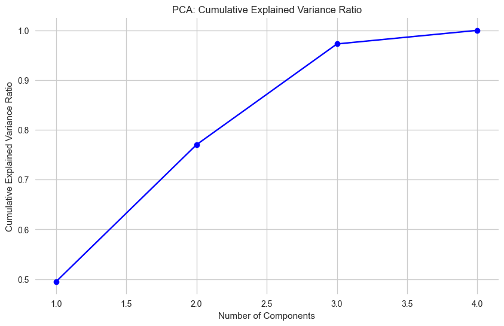

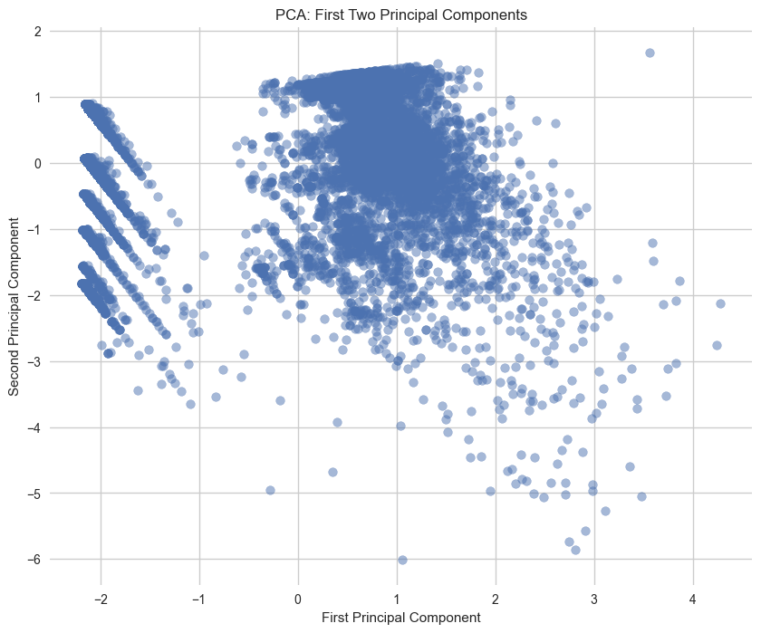

```
Analysis of interactions between multiple variables is complete.
```

```python
# Plot explained variance ratio
plt.figure(figsize=(10, 6))
plt.plot(range(1, len(pca.explained_variance_ratio_) + 1), pca.explained_variance_ratio_.cumsum(), 'bo-')
plt.xlabel('Number of Components')
plt.ylabel('Cumulative Explained Variance Ratio')
plt.title('PCA: Cumulative Explained Variance Ratio')
plt.show()

# Plot first two principal components
plt.figure(figsize=(10, 8))
plt.scatter(netflix_pca[:, 0], netflix_pca[:, 1], alpha=0.5)
plt.xlabel('First Principal Component')
plt.ylabel('Second Principal Component')
plt.title('PCA: First Two Principal Components')
plt.show()

print("Analysis of interactions between multiple variables is complete.")
```

## Multivariate Analysis - Conclusion:

I conducted Multivariate analysis on multiple variables, below I have listed my findings after conducting this analysis and also few examples of how the plots look like Correlation Analysis:

● ‘Rating_encoded’ has weak correlation with other variables, showing that the duration and the release are not much dependent on content rating.

Pairwise Relationships:

● The plot of ‘release_year’ is heavily skewed towards recent years, with a good increase in content from the year 2015 onwards.

Some findings:

● The spread of points along PC1 should represent the variation in release years or durations

● Any kind of outliers present in the plots could represent a unique content in the netflix catalog

● There might be two main clusters, corresponding to our two main variables which are “Movies” and “Tv shows”

This multivariate analysis reveals complex relationships between duration, content type, release year and rating in the netflix catalog. It showcases how the platform is recently focused on mature content, with a mix of shows and movies catering to a diverse international audience. These insights could be valuable for developing a good recommendation system that takes care of multiple factors when suggesting content to users

## Step - 4: Usage of Functions

```
Mean duration: 69.82 minutes
Standard deviation of duration: 50.82 minutes

Content type counts:
 type
Movie      6131
TV Show    2676
Name: count, dtype: int64
```

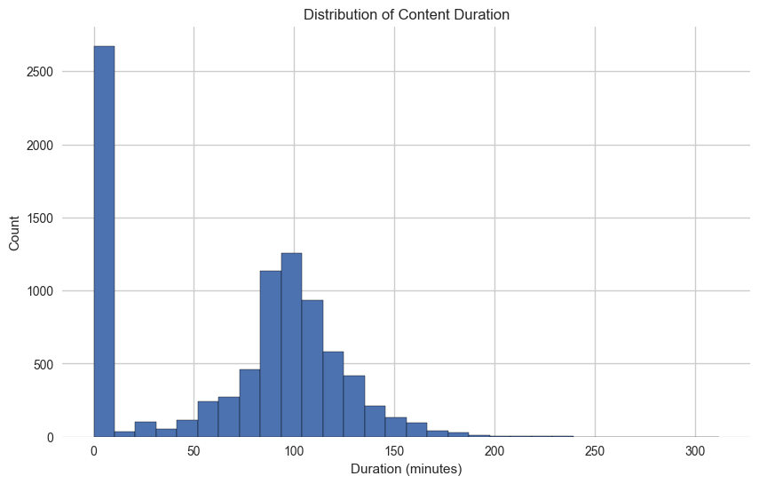

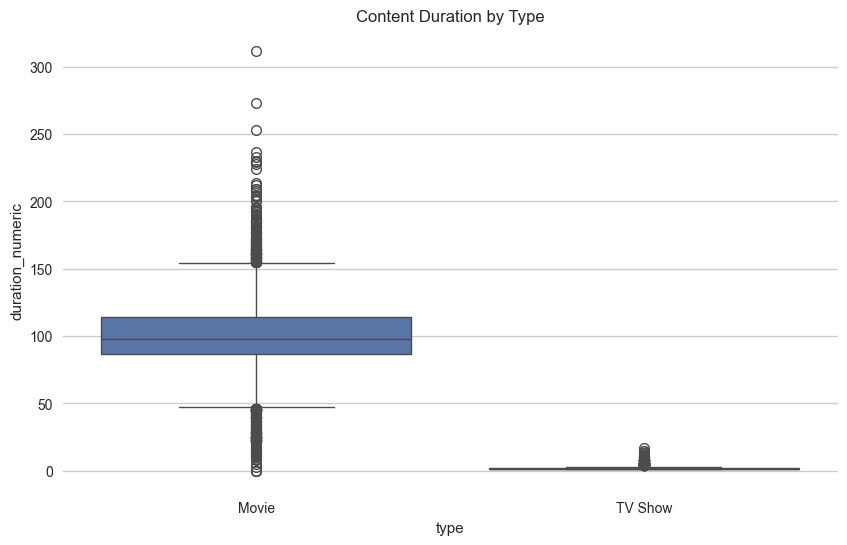

```python
import pandas as pd
import numpy as np
import matplotlib.pyplot as plt
import seaborn as sns

# pandas are used to Load and preprocess the data
def load_and_preprocess_data(file_path):
    # Use pandas to read the CSV file
    df = pd.read_csv(file_path)

    # Use pandas to handle missing values
    df['duration'] = df['duration'].fillna('0 min')

    # Use pandas to extract numeric duration
    df['duration_numeric'] = df['duration'].str.extract(r'(\d+)').astype(float)

    return df

# NumPy is used to Perform statistical analysis
def analyze_data(df):
    # Use numpy to calculate mean and standard deviation
    mean_duration = np.mean(df['duration_numeric'])
    std_duration = np.std(df['duration_numeric'])

    print(f"Mean duration: {mean_duration:.2f} minutes")
    print(f"Standard deviation of duration: {std_duration:.2f} minutes")

    # Use pandas for groupby operations
    type_counts = df['type'].value_counts()
    print("\nContent type counts:\n", type_counts)

# Matplotlib is used to Create visualizations
def visualize_data(df):
    # Use matplotlib to create a histogram
    plt.figure(figsize=(10, 6))
    plt.hist(df['duration_numeric'], bins=30, edgecolor='black')
    plt.title('Distribution of Content Duration')
    plt.xlabel('Duration (minutes)')
    plt.ylabel('Count')
    plt.show()

    # Seaborn is used for Advanced Statistical Analysis
    plt.figure(figsize=(10, 6))
    sns.boxplot(x='type', y='duration_numeric', data=df)
    plt.title('Content Duration by Type')
    plt.show()

# Main function to run the analysis
def main():
    df = load_and_preprocess_data('netflix_titles.csv')
    analyze_data(df)
    visualize_data(df)

if __name__ == "__main__":
    main()
```

## Pandas:

● The code mostly uses pandas for data analysis and manipulation

● Dataframe consists of operations like .describe(), .info(), and .value_counts(), which is useful in providing the summary of the data

● Groupby operations in pandas is helpful in showcasing pandas ability to split-apply-combine data much efficiently

## Numpy:

● Numpy is a function that is used for numerical computing on arrays.

● It consists of functions like np.percentile(), np.std(), np.mean() and np.median() which are used to calculate various statistical measures

## Matplotlib:

● This is the main foundation of creating visualisations

● This is also used in setting the size of the figure, tables and titles and is helpful in customising the plots

## Seaborn:

● Seaborn is something that is built on matplotlib and is used to showcase advanced statistical visualisations.

● The visuals such as heatmap are used to correlate between numeric variables and demonstrate seaborn’s statistical plotting capabilities

## EDA Answers

1. How does the distribution of release years for Netflix content compare to the typical bell curve, and what does this suggest about Netflix's content acquisition strategy?

Answer: The distribution of release years for Netflix content is heavily skewed towards recent years, unlike a typical bell curve. The mean release year is 2014.18, with a median of 2017 and a mode of 2018. The distribution has a strong negative skewness (-3.45) and high kurtosis (16.23), indicating a concentration of content in recent years. This suggests that Netflix's content acquisition strategy strongly favors newer content, likely to keep their library fresh and appealing to viewers who prefer recent releases.

## 5. Summary

## Content Distribution:

● The dataset contains 8,807 titles which is divided into 6,131 movies (69.6%) and 2,676 TV shows (30.4%)

● Release of the content varies from 1925 to 2021, with a mean of 2014 and median of 2017

## Duration:

● The average duration of the content is 69.85 minutes and it has a median of 88 minutes.

● There is wide range of durations of content with minimum being 1 minute of content to 312 minutes of content

## Ratings:

● The most common rating is TV-MA (3207 titles), followed by TV-14 (2,160 titles).

## Content Origin:

● United States is the primary source of content in netflix with releasing over (2818 titles) and then they are followed by india who released over (972 titles) until now

## Genres:

● Following to these genres we also have documentaries and stand-up comedies being featured prominently

## Release Year Distribution:

● The distribution of release years is highly peaked and heavily skewed towards recent years

● Also we could notice a sharp increase in content release from 2015.

## Insights

1. Content Strategy: Netflix appears to be more focused on mature content with a strong emphasis on movies. This gives us an idea to focus more on adult audiences and staying current with new releases
2. Global Research: The increase in international content, especially from India, showcases Netflix’s global expansion strategy and effort to make their content available for all the regions.
3. Content Length: The wide range of durations, mostly for movies, shows Netflix’s flexibility in content format and potentially taking care of different viewing habits
4. Genere Focus: The impact of international movies and dramas suggests that these genres are the most popular ones among Netflix users, the platform might be using this data to make good production decisions and informed content acquisition.
5. Recent Content Emphasis: The skew which was seen in the graph shows that Netflix is constantly updating their library with new content, and this could be a key factor in retaining subscribers
6. Mature Content preference: The viewing of content which is rated TV-MA and TV-14 suggests that Netflix’s core audience may be older teens or adults

## Limitations:

1. Time Sensitivity: The dataset only has data till the year 2021, so it might not tell us about most recent trends on the platform
2. Lack of Viewing Data: The dataset does not have much information on popularity and viewership, which could be good to provide more insights into content performance
3. Genre Classification: The ‘listed_in’ column has information on multiple genres, making it difficult for genre-based analysis
4. Content Changes: Netflix’s catalog changes very frequently, so this static dataset might not be that accurate and represent current offering

## Future Work

1. Content Recommendation System: Develop a more sophisticated recommendation algorithm using the insights gained from this analysis, potentially incorporating machine learning techniques like collaborative filtering or content-based filtering.
2. Temporal Analysis: Conduct a more in-depth analysis of how Netflix's content strategy has evolved over time, looking at trends in genres, ratings, and content types across different years.
3. User Engagement Prediction: Develop a model to predict potential user engagement based on content attributes like duration, genre, and rating.
4. Genre Classification: Create a more robust genre classification system, possibly using natural language processing on the 'description' field to extract more detailed genre information.
5. Predictive Modeling for Content Success: Develop a model to predict the potential success of new content based on attributes present in the dataset.

These five options offer a good balance of advanced analytics, machine learning applications, and strategic insights that could significantly enhance understanding of Netflix's content strategy and user engagement patterns.

## References

Gomez-Uribe, C. A., & Hunt, N. (2015). The Netflix recommender system: Algorithms, business value, and innovation. ACM Transactions on Management Information Systems (TMIS), 6(4), 1-19. Link: https://dl.acm.org/doi/10.1145/2843948

Basilico, J., & Raimond, Y. (2017). Déjà View: Leveraging Viewing History to Improve Content Recommendations. In RecSys 2017 Poster Proceedings. Link: https://dl.acm.org/doi/10.1145/3109859.3109981

Amatriain, X., & Basilico, J. (2012). Netflix recommendations: Beyond the 5 stars (part 1). Netflix Tech Blog, 6. Link: https://netflixtechblog.com/netflix-recommendations-beyond-the-5-stars-part-1-55838468f429

NumPy: https://numpy.org/doc/stable/

Pandas: https://pandas.pydata.org/docs/

Matplotlib: https://matplotlib.org/stable/contents.html

Seaborn: https://seaborn.pydata.org/